# Goal

> For this project, I'm going to build a machine learning model that could predict the property sales price for properties in NYC. I'm dividing my project into the following sections:
> - EDA
> - Data Preparation
> - Modelling

[figure not shown]

> Source

# EDA, Feature Engineering, and AutoML

> We will apply learned concepts from Day 3-4 lectures to perform `data exploration`, `feature engineering`, and `autoML` on a `House Sale` dataset.
> - The goal of this assignment is to analyze 3 years’`(2018-2020) House Sales` data provided by `New York City` (NYC) government and build regression model to predict house price.
> - NYC has five boroughs, i.e., `Bronx`, `Brooklyn`, `Manhattan`, `Queens` and `Staten Island`.
> - Sales of houses in each borough has been provided.

# Task 1: Read dataset, merge data, and perform basic data exploration.

> **Note,** you should briefely discuss the quality of dataset (`missing values`, `duplicate entries`, etc.)

> Also, in `task 3`, you would be asked to perform prediction on house sale price, thus it would be good to consider outliers related to this prediciton task when you perform data cleaning.

```python
df
```

|  | BOROUGH | NEIGHBORHOOD | BUILDING CLASS CATEGORY | TAX CLASS AT PRESENT | BLOCK | LOT | EASE-MENT | BUILDING CLASS AT PRESENT | ADDRESS | APARTMENT NUMBER | ... | RESIDENTIAL UNITS | COMMERCIAL UNITS | TOTAL UNITS | LAND SQUARE FEET | GROSS SQUARE FEET | YEAR BUILT | TAX CLASS AT TIME OF SALE | BUILDING CLASS AT TIME OF SALE | SALE PRICE | SALE DATE |
| --- | --- | --- | --- | --- | --- | --- | --- | --- | --- | --- | --- | --- | --- | --- | --- | --- | --- | --- | --- | --- | --- |
| 0 | 5.0 | ANNADALE | 01 ONE FAMILY DWELLINGS | 1 | 5404.0 | 46.0 | NaN | A1 | 119 LENZIE STREET | NaN | ... | 1.0 | 0.0 | 1.0 | 8,000 | 3,660 | 1998.0 | 1.0 | A1 | 315,000 | 2020-10-02 |
| 1 | 5.0 | ANNADALE | 01 ONE FAMILY DWELLINGS | 1 | 5407.0 | 6.0 | NaN | A1 | 118 ELMBANK STREET | NaN | ... | 1.0 | 0.0 | 1.0 | 6,200 | 2,580 | 1975.0 | 1.0 | A1 | 450,000 | 2020-06-24 |
| 2 | 5.0 | ANNADALE | 01 ONE FAMILY DWELLINGS | 1 | 5425.0 | 31.0 | NaN | A1 | 7 SANDGAP STREET | NaN | ... | 1.0 | 0.0 | 1.0 | 2,500 | 1,222 | 1925.0 | 1.0 | A2 | 525,000 | 2020-07-02 |
| 3 | 5.0 | ANNADALE | 01 ONE FAMILY DWELLINGS | 1 | 6205.0 | 17.0 | NaN | A5 | 91 EAGAN AVENUE | NaN | ... | 1.0 | 0.0 | 1.0 | 1,845 | 1,854 | 1986.0 | 1.0 | A5 | 480,000 | 2020-01-14 |
| 4 | 5.0 | ANNADALE | 01 ONE FAMILY DWELLINGS | 1 | 6205.0 | 83.0 | NaN | A1 | 7 SEGUINE PLACE | NaN | ... | 1.0 | 0.0 | 1.0 | 3,989 | 2,300 | 2004.0 | 1.0 | A1 | 720,000 | 2020-10-15 |
| ... | ... | ... | ... | ... | ... | ... | ... | ... | ... | ... | ... | ... | ... | ... | ... | ... | ... | ... | ... | ... | ... |
| 277798 | NaN | NaN | NaN | NaN | NaN | NaN | NaN | NaN | NaN | NaN | ... | NaN | NaN | NaN | NaN | NaN | NaN | NaN | NaN | NaN | NaN |
| 277799 | NaN | NaN | NaN | NaN | NaN | NaN | NaN | NaN | NaN | NaN | ... | NaN | NaN | NaN | NaN | NaN | NaN | NaN | NaN | NaN | NaN |
| 277800 | NaN | NaN | NaN | NaN | NaN | NaN | NaN | NaN | NaN | NaN | ... | NaN | NaN | NaN | NaN | NaN | NaN | NaN | NaN | NaN | NaN |
| 277801 | NaN | NaN | NaN | NaN | NaN | NaN | NaN | NaN | NaN | NaN | ... | NaN | NaN | NaN | NaN | NaN | NaN | NaN | NaN | NaN | NaN |
| 277802 | NaN | NaN | NaN | NaN | NaN | NaN | NaN | NaN | NaN | NaN | ... | NaN | NaN | NaN | NaN | NaN | NaN | NaN | NaN | NaN | NaN |

277803 rows × 21 columns

# Exploratory Data Analysis (EDA)

> The EDA is divided in the following steps:
> 1. Basic data exploration
> 2. Identification of variables and data types
> 3. Missing values
> 4. Univariate Analysis
> 5. Bivariate Analysis
> 6. Correlation matrix
> 7. Conclusion

## 1. Basic data exploration

> The basic data exploration includes the following pandas methods:
> 1. `info()` for printing a summary about the columns and data types in the dataframe.
> 2. `describe()` for showing statistical information about the nummerical values in the dataframe.
> 3. `head()` for showing the first 5 rows in the dataframe.

> If we want to see what all the data types are in a dataframe, use `df.dtypes` or the `df.info()` function shows even more useful info.

```python
# summary of the data including non-null counts

# df.dtypes
df.info()
```

```
<class 'pandas.core.frame.DataFrame'>
Int64Index: 277803 entries, 149400 to 277802
Data columns (total 21 columns):
 #   Column                          Non-Null Count   Dtype
---  ------                          --------------   -----
 0   BOROUGH                         230659 non-null  float64
 1   NEIGHBORHOOD                    230659 non-null  object
 2   BUILDING CLASS CATEGORY         230659 non-null  object
 3   TAX CLASS AT PRESENT            230386 non-null  object
 4   BLOCK                           230659 non-null  float64
 5   LOT                             230659 non-null  float64
 6   EASE-MENT                       0 non-null       float64
 7   BUILDING CLASS AT PRESENT       230386 non-null  object
 8   ADDRESS                         230659 non-null  object
 9   APARTMENT NUMBER                50782 non-null   object
 10  ZIP CODE                        230642 non-null  float64
 11  RESIDENTIAL UNITS               199734 non-null  object
 12  COMMERCIAL UNITS                189268 non-null  object
 13  TOTAL UNITS                     201363 non-null  object
 14  LAND SQUARE FEET                187638 non-null  object
 15  GROSS SQUARE FEET               187639 non-null  object
 16  YEAR BUILT                      220373 non-null  float64
 17  TAX CLASS AT TIME OF SALE       230659 non-null  float64
 18  BUILDING CLASS AT TIME OF SALE  230659 non-null  object
 19  SALE PRICE                      230659 non-null  object
 20  SALE DATE                       230659 non-null  object
dtypes: float64(7), object(14)
memory usage: 46.6+ MB
```

> **Notes on the previous cell** :

> After looking at the automatically assigned data types, the types of data are `float` and `object`

```python
df.describe()
```

|  | BOROUGH | BLOCK | LOT | EASE-MENT | ZIP CODE | YEAR BUILT | TAX CLASS AT TIME OF SALE |
| --- | --- | --- | --- | --- | --- | --- | --- |
| count | 230659.000000 | 230659.000000 | 230659.000000 | 0.0 | 230642.000000 | 220373.000000 | 230659.000000 |
| mean | 3.019045 | 4422.239262 | 357.502035 | NaN | 10844.556651 | 1892.753795 | 1.619104 |
| std | 1.274595 | 3655.509089 | 653.040020 | NaN | 725.670609 | 332.153910 | 0.801899 |
| min | 1.000000 | 1.000000 | 1.000000 | NaN | 0.000000 | 0.000000 | 1.000000 |
| 25% | 2.000000 | 1366.000000 | 22.000000 | NaN | 10307.000000 | 1921.000000 | 1.000000 |
| 50% | 3.000000 | 3558.000000 | 49.000000 | NaN | 11210.000000 | 1941.000000 | 1.000000 |
| 75% | 4.000000 | 6574.000000 | 316.000000 | NaN | 11358.000000 | 1970.000000 | 2.000000 |
| max | 5.000000 | 16350.000000 | 9116.000000 | NaN | 11697.000000 | 2021.000000 | 4.000000 |

> Through my use of `duplicated()` function with **Parameter** : `subset=None` to consider all attributes for identifying duplicates and to remove those duplicates have been used `drop_duplicates()` function.

```python
# use the DataFrame.duplicated() method to return a series of boolean values
df.duplicated(subset=None)
```

```
149400    False
43817     False
43818     False
43819     False
43820     False
          ...
277798     True
277799     True
277800     True
277801     True
277802     True
Length: 277803, dtype: bool
```

> **Notes on the previous cell** :

> Because of the large amount of data, we cannot determine whether there is duplicates or not, so we need to use `unique()` or `sum()`

```python
# dropping ALL duplicate values
df = df.drop_duplicates()
```

```python
# To make sure everything is working fine.
df.duplicated().sum()
```

```
0
```

## 2. Identification of variables and data types

> For this part of the EDA I'm identifying the type of variables in the dataset. It is imporant for an EDA to know with what kind of variables you are dealing with. There are two types of variables:
> 1. Categorical
> 2. Numerical

> For this step, I'm creating two lists for each dataset where I'm saving the different columns.

> BOROUGH: A digit code for the borough the property is located in; in order these are `Manhattan` (1), `Bronx` (2), `Brooklyn` (3), `Queens` (4), and `Staten Island` (5).

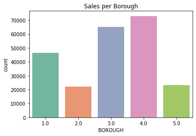

```python
sns.countplot('BOROUGH',data=df,palette='Set2')
plt.title('Sales per Borough')
```

> For this step, I'm creating two lists for each dataset where I'm saving the different columns. It allows me to write less code and saves me some time. I'm using conditional logic to assign the right columns to the data type list where it belongs.

```python
# Select categorical columns
categorical_cols_re = [cname for cname in df.columns if df[cname].dtype == "object"]
# Select numerical columns
numerical_cols_re = [cname for cname in df.columns if df[cname].dtype in ['int64', 'float64']]

# Print the columns
print(f'There are {len(categorical_cols_re)} categorical columns in this dataset. \nThe columns are: {categorical_cols_re}. \n')
print(f'There are {len(numerical_cols_re)} numerical columns in this dataset. \nThe columns are: {numerical_cols_re}.')
```

```
There are 14 categorical columns in this dataset.
The columns are: ['NEIGHBORHOOD', 'BUILDING CLASS CATEGORY', 'TAX CLASS AT PRESENT', 'BUILDING CLASS AT PRESENT', 'ADDRESS', 'APARTMENT NUMBER', 'RESIDENTIAL UNITS', 'COMMERCIAL UNITS', 'TOTAL UNITS', 'LAND SQUARE FEET', 'GROSS SQUARE FEET', 'BUILDING CLASS AT TIME OF SALE', 'SALE PRICE', 'SALE DATE…

There are 7 numerical columns in this dataset.
The columns are: ['BOROUGH', 'BLOCK', 'LOT', 'EASE-MENT', 'ZIP CODE', 'YEAR BUILT', 'TAX CLASS AT TIME OF SALE'].
```

## 3. Missing values and data cleaning

> For this step of the project, I'm checking for missing values in the datasets.

#### We will start with `SALE PRICE` column

> If a column contains a lot of missing values, say more than `50%` , and the feature is not significant, you might want to delete that feature.

```python
# we will call this method several time
def ratio_meth():
  # you can also count the ratio of missing values
  total_miss = df.isnull().sum()
  # Percentage of missing values
  percent_miss = (total_miss/df.isnull().count()*100)

  # sort attributes by missing value ratio
  missing_data = pd.DataFrame({'Total missing':total_miss,'% missing':percent_miss})
  print(missing_data.sort_values(by='Total missing',ascending=False))

ratio_meth()
```

```
                                Total missing   % missing
EASE-MENT                              229893  100.000000
APARTMENT NUMBER                       179274   77.981496
LAND SQUARE FEET                        42966   18.689564
GROSS SQUARE FEET                       42965   18.689129
COMMERCIAL UNITS                        41336   17.980539
RESIDENTIAL UNITS                       30879   13.431901
TOTAL UNITS                             29250   12.723310
YEAR BUILT                              10276    4.469906
TAX CLASS AT PRESENT                      274    0.119186
BUILDING CLASS AT PRESENT                 274    0.119186
ZIP CODE                                   18    0.007830
SALE PRICE                                  1    0.000435
BUILDING CLASS AT TIME OF SALE              1    0.000435
TAX CLASS AT TIME OF SALE                   1    0.000435
BOROUGH                                     1    0.000435
NEIGHBORHOOD                                1    0.000435
ADDRESS                                     1    0.000435
LOT                                         1    0.000435
BLOCK                                       1    0.000435
BUILDING CLASS CATEGORY                     1    0.000435
SALE DATE                                   1    0.000435
```

```python
# source : thispointer.com/pandas-drop-dataframe-columns-based-on-nan-percentage/

# Delete columns containing either 50% or more than 50% NaN Values
perc = 50.0
min_count =  int(((100-perc)/100)*df.shape[0] + 1)
df = df.dropna( axis=1, thresh=min_count)
```

> And also we can't deal with a row with missing value in `SALE PRICE` column

```python
# Remove observations with missing SALE PRICE
df = df[df['SALE PRICE'].notnull()]
len(df)
```

```
229892
```

```python
# To make sure everything is working fine.
# just call this fun.
ratio_meth()
```

```
                                Total missing  % missing
LAND SQUARE FEET                        42965  18.689211
GROSS SQUARE FEET                       42964  18.688776
COMMERCIAL UNITS                        41335  17.980182
RESIDENTIAL UNITS                       30878  13.431524
TOTAL UNITS                             29249  12.722931
YEAR BUILT                              10275   4.469490
TAX CLASS AT PRESENT                      273   0.118751
BUILDING CLASS AT PRESENT                 273   0.118751
ZIP CODE                                   17   0.007395
SALE PRICE                                  0   0.000000
BUILDING CLASS AT TIME OF SALE              0   0.000000
TAX CLASS AT TIME OF SALE                   0   0.000000
BOROUGH                                     0   0.000000
NEIGHBORHOOD                                0   0.000000
ADDRESS                                     0   0.000000
LOT                                         0   0.000000
BLOCK                                       0   0.000000
BUILDING CLASS CATEGORY                     0   0.000000
SALE DATE                                   0   0.000000
```

> `SALE PRICE` is object but we need convert it into numeric such as ( `2,100,000` = `2100000`)

> **Note:** we also noticed that there are some values with `$0` and `0` , we need to handle that

```python
df['SALE PRICE'][:20]
```

```
149400           $0
43817     2,100,000
43818     2,121,000
43819     1,512,500
43820       624,000
43821       635,000
43822     2,525,000
43823     6,800,000
43824             0
43825       825,000
43826             0
43816     1,900,000
43827            10
43829     1,100,000
43830             0
43831       987,500
43832     4,950,000
43833     4,995,000
43834     1,505,000
43835       940,000
Name: SALE PRICE, dtype: object
```

```python
df['SALE PRICE'] = df['SALE PRICE'].str.replace(',', '')
df['SALE PRICE'] = df['SALE PRICE'].str.replace('$', '')
```

```python
df['SALE PRICE']
```

```
149400          0
43817     2100000
43818     2121000
43819     1512500
43820      624000
           ...
56385      450000
56386      500000
56387      595000
56376      618500
0          315000
Name: SALE PRICE, Length: 229892, dtype: object
```

```python
type(df['SALE PRICE'][0])
```

```
str
```

> SALE PRICE is string now but should to convert it to numeric

```python
# converting fun.
df['SALE PRICE'] = pd.to_numeric(df['SALE PRICE'], errors='coerce')
```

```python
type(df['SALE PRICE'][0])
```

```
numpy.int64
```

#### The next column is (`BUILDING CLASS AT PRESENT` & `TAX CLASS AT PRESENT`)

> As we can see that these two columns `TAX CLASS AT PRESENT` & `TAX CLASS AT TIME OF SALE` represent the same information, so we don't need to process these missing values for `TAX CLASS AT PRESENT` column, we will drop it because the other column `TAX CLASS AT TIME OF SALE` has no missing values.

```python
#find out the TCATOS where TCAP are missing

tcap = list(df[df['TAX CLASS AT PRESENT'].isna()]['TAX CLASS AT TIME OF SALE'])


#Find out TCAP associated with these TCATOS

tcap_df = df[df['TAX CLASS AT TIME OF SALE'].isin(tcap)]

tcap_df[['TAX CLASS AT PRESENT','TAX CLASS AT TIME OF SALE']]
```

|  | TAX CLASS AT PRESENT | TAX CLASS AT TIME OF SALE |
| --- | --- | --- |
| 149400 | 2 | 2.0 |
| 43817 | 2 | 2.0 |
| 43818 | 2 | 2.0 |
| 43819 | 2 | 2.0 |
| 43820 | 2 | 2.0 |
| ... | ... | ... |
| 56385 | 1 | 1.0 |
| 56386 | 1 | 1.0 |
| 56387 | 1 | 1.0 |
| 56376 | 1 | 1.0 |
| 0 | 1 | 1.0 |

229892 rows × 2 columns

```python
#drop column fun.
df.drop(['TAX CLASS AT PRESENT'], axis = 1, inplace = True)
```

> As we can see that these two columns `BUILDING CLASS AT PRESENT` & `BUILDING CLASS AT TIME OF SALE` represent the same information, so we don't need to process these missing values for `BUILDING CLASS AT PRESENT` column, we will drop it because the other column `BUILDING CLASS AT TIME OF SALE` has no missing values.

```python
#find out the TCATOS where TCAP are missing

tcap = list(df[df['BUILDING CLASS AT PRESENT'].isna()]['BUILDING CLASS AT TIME OF SALE'])


#Find out TCAP associated with these TCATOS

tcap_df = df[df['BUILDING CLASS AT TIME OF SALE'].isin(tcap)]

tcap_df[['BUILDING CLASS AT PRESENT','BUILDING CLASS AT TIME OF SALE']]
```

|  | BUILDING CLASS AT PRESENT | BUILDING CLASS AT TIME OF SALE |
| --- | --- | --- |
| 43823 | RR | RR |
| 43826 | R4 | R4 |
| 43827 | R4 | R4 |
| 43829 | R4 | R4 |
| 43830 | R4 | R4 |
| ... | ... | ... |
| 233110 | A5 | A5 |
| 233108 | A5 | A5 |
| 56266 | B3 | B3 |
| 56268 | B3 | B3 |
| 56183 | B3 | B3 |

51137 rows × 2 columns

```python
#drop column fun.
df.drop(['BUILDING CLASS AT PRESENT'], axis = 1, inplace = True)
```

#### The next column is (`ZIP CODE`)

> The percentage of empty rows in this column is very small compared to the size of the data, so it is possible to drop these rows

```python
# To make sure everything is working fine.
# just call this fun.
ratio_meth()
```

```
                                Total missing  % missing
LAND SQUARE FEET                        42965  18.689211
GROSS SQUARE FEET                       42964  18.688776
COMMERCIAL UNITS                        41335  17.980182
RESIDENTIAL UNITS                       30878  13.431524
TOTAL UNITS                             29249  12.722931
YEAR BUILT                              10275   4.469490
ZIP CODE                                   17   0.007395
SALE PRICE                                  0   0.000000
BUILDING CLASS AT TIME OF SALE              0   0.000000
TAX CLASS AT TIME OF SALE                   0   0.000000
BOROUGH                                     0   0.000000
NEIGHBORHOOD                                0   0.000000
ADDRESS                                     0   0.000000
LOT                                         0   0.000000
BLOCK                                       0   0.000000
BUILDING CLASS CATEGORY                     0   0.000000
SALE DATE                                   0   0.000000
```

```python
#drop all the nulls values fun.
df.dropna(axis = 'rows', subset = ['ZIP CODE'], inplace = True)
```

#### The next column is (`LAND SQUARE FEET` & `GROSS SQUARE FEET`)

> As we can see there are a high correlation for both of these columns. It's a type of `MAR` methodology.

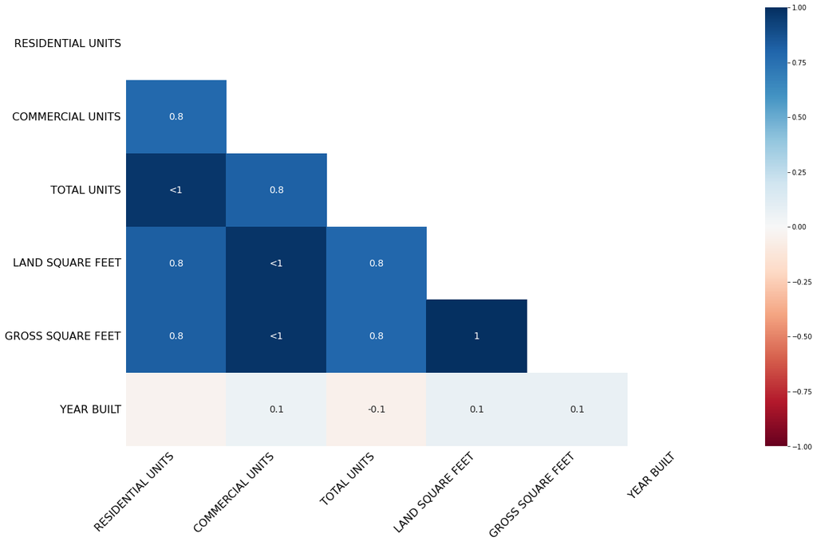

```python
#heapmap for correlation analysis
msno.heatmap(df)
```

```python
#find out the TCATOS where TCAP are missing

tcap = list(df[df['LAND SQUARE FEET'].isna()]['GROSS SQUARE FEET'])


#Find out TCAP associated with these TCATOS

tcap_df = df[df['GROSS SQUARE FEET'].isin(tcap)]

len(tcap_df[['LAND SQUARE FEET','GROSS SQUARE FEET']])
```

```
42963
```

```python
#convert categorical to numerical
df['LAND SQUARE FEET'] = df['LAND SQUARE FEET'].str.replace(',', '')
df['GROSS SQUARE FEET'] = df['GROSS SQUARE FEET'].str.replace(',', '')
```

> we need to handle both of these columns with `Iterative Imputer` class .

```python
# create a list with columns names .
col_names = ['LAND SQUARE FEET', 'GROSS SQUARE FEET']

# Use IterativeImputer to predict missing values.
imputer = IterativeImputer(max_iter=10)
# Fit to data, then transform it.
df[col_names] = imputer.fit_transform(df[col_names])
```

```python
# To make sure everything is working fine.
# just call this fun.
ratio_meth()
```

```
                                Total missing  % missing
COMMERCIAL UNITS                        41333  17.980642
RESIDENTIAL UNITS                       30876  13.431648
TOTAL UNITS                             29247  12.723002
YEAR BUILT                              10259   4.462860
SALE PRICE                                  0   0.000000
BUILDING CLASS AT TIME OF SALE              0   0.000000
TAX CLASS AT TIME OF SALE                   0   0.000000
GROSS SQUARE FEET                           0   0.000000
LAND SQUARE FEET                            0   0.000000
BOROUGH                                     0   0.000000
NEIGHBORHOOD                                0   0.000000
ZIP CODE                                    0   0.000000
ADDRESS                                     0   0.000000
LOT                                         0   0.000000
BLOCK                                       0   0.000000
BUILDING CLASS CATEGORY                     0   0.000000
SALE DATE                                   0   0.000000
```

#### The next column is (`YEAR BUILT`)

> I had an idea so we could handle that column in a better way than mean , median and mode which is to fill the missing values in `Year Built` with the corresponding value of `Sale Date` column .

> Considering that the year of sale of the lost house, the value of the year of construction is the same as the year of its purchase

```python
# get the type of this column
print(df['SALE DATE'].dtype)
# convert it into date type
df['SALE DATE'] = pd.to_datetime(df['SALE DATE'])
print(df['SALE DATE'].dtype)

# create two new columns
df['YEAR SOLD'] = (df['SALE DATE']).dt.year
df['MONTH SOLD']= (df['SALE DATE']).dt.month
```

```
object
datetime64[ns]
```

```python
# to fill the missing values in year build column
df['YEAR BUILT'] = df['YEAR BUILT'].fillna(df['YEAR SOLD'])
```

```python
# convert the column into int type
df['YEAR BUILT'] = df['YEAR BUILT'].astype(int)
```

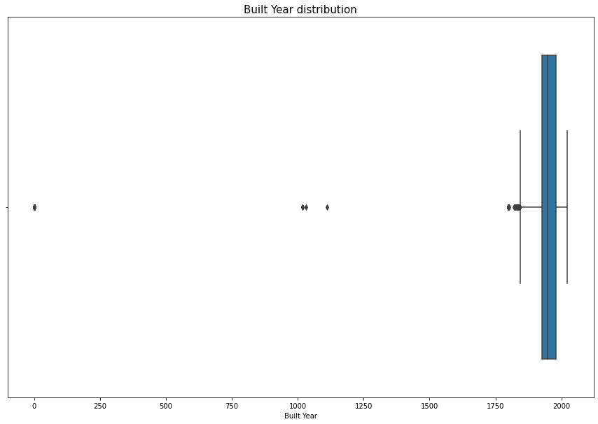

```python
# Figure size and theme
plt.figure(figsize=(15,10))

# Plot the data
sns.boxplot(df['YEAR BUILT'])

plt.title('Built Year distribution',fontsize=15)
plt.xlabel('Built Year')
plt.show()
```

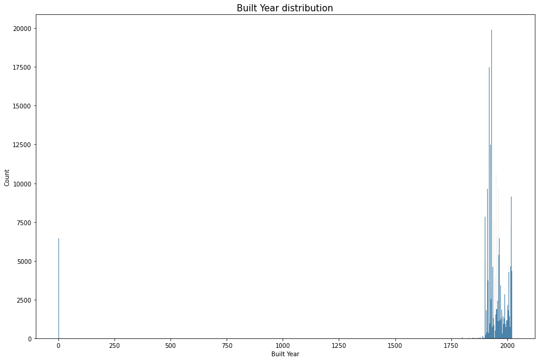

```python
# Figure size and theme
plt.figure(figsize=(15,10))

# Plot the data
sns.histplot(df['YEAR BUILT'])

plt.title('Built Year distribution',fontsize=15)
plt.xlabel('Built Year')
plt.show()
```

#### List of the oldest buildings in New York

> The oldest building in New York State was first built in `1652`

> Therefore, we can handle outliers in this simple way.

[figure not shown]

> this is a photo of the oldest building in the NY if you want to take a look at it 😃

> [source](https://en.wikipedia.org/wiki/List_of_the_oldest_buildings_in_New_York)

```python
#creating a dataframe without zero values for year built column
df = df[df['YEAR BUILT'] >= 1652]
```

> As we can see, the distribution has become much better.

> But we can use other methods later.

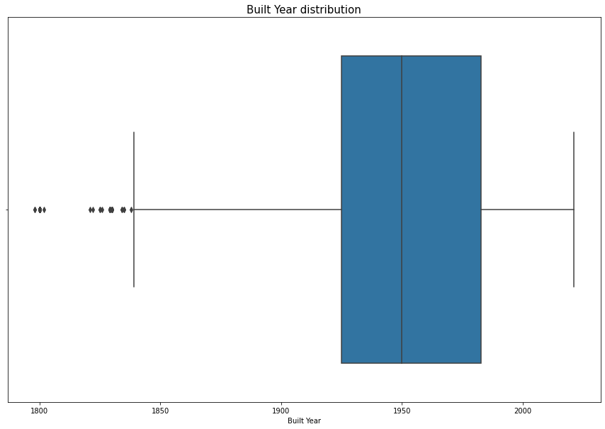

```python
# Figure size and theme
plt.figure(figsize=(15,10))

# Plot the data
sns.boxplot(df['YEAR BUILT'])

plt.title('Built Year distribution',fontsize=15)
plt.xlabel('Built Year')
plt.show()
```

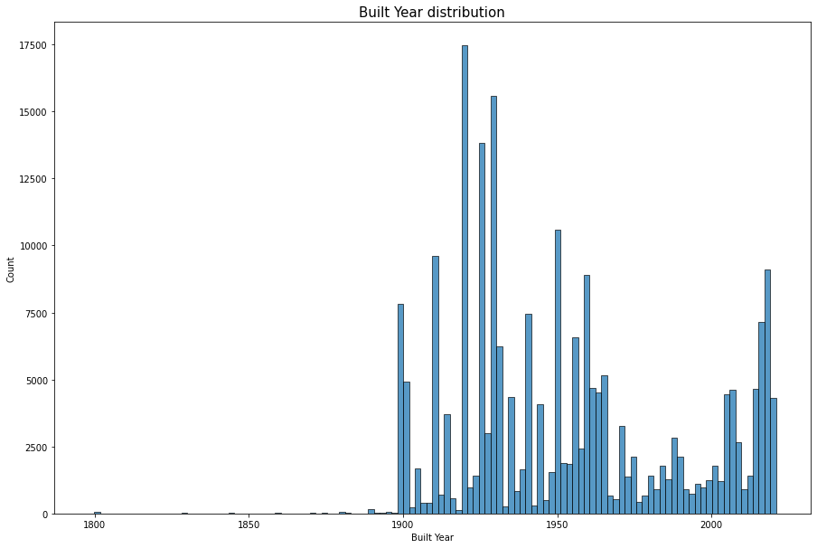

```python
# Figure size and theme
plt.figure(figsize=(15,10))

# Plot the data
sns.histplot(df['YEAR BUILT'])

plt.title('Built Year distribution',fontsize=15)
plt.xlabel('Built Year')
plt.show()
```

#### The next column is (`COMMERCIAL UNITS` & `RESIDENTIAL UNITS` & `TOTAL UNITS`)

> I think there is an observation for this missing related with the industry of the real state but unfortunately i don't know it.

> So we will handle it with `IterativeImputer` class.

```python
# just call this fun.
ratio_meth()
```

```
                                Total missing  % missing
COMMERCIAL UNITS                        41333  18.499637
RESIDENTIAL UNITS                       30876  13.819341
TOTAL UNITS                             29247  13.090240
GROSS SQUARE FEET                           0   0.000000
YEAR SOLD                                   0   0.000000
SALE DATE                                   0   0.000000
SALE PRICE                                  0   0.000000
BUILDING CLASS AT TIME OF SALE              0   0.000000
TAX CLASS AT TIME OF SALE                   0   0.000000
YEAR BUILT                                  0   0.000000
BOROUGH                                     0   0.000000
LAND SQUARE FEET                            0   0.000000
NEIGHBORHOOD                                0   0.000000
ZIP CODE                                    0   0.000000
ADDRESS                                     0   0.000000
LOT                                         0   0.000000
BLOCK                                       0   0.000000
BUILDING CLASS CATEGORY                     0   0.000000
MONTH SOLD                                  0   0.000000
```

```python
#convert categorical to numerical
df['TOTAL UNITS'] = pd.to_numeric(df['TOTAL UNITS'], errors='coerce')
df['COMMERCIAL UNITS'] = pd.to_numeric(df['COMMERCIAL UNITS'], errors='coerce')
df['RESIDENTIAL UNITS'] = pd.to_numeric(df['RESIDENTIAL UNITS'], errors='coerce')
```

```python
# create a list with columns names .
col_names = ['COMMERCIAL UNITS' , 'RESIDENTIAL UNITS' , 'TOTAL UNITS']

# Use IterativeImputer to predict missing values.
imputer = IterativeImputer(max_iter=10)
# Fit to data, then transform it.
df[col_names] = imputer.fit_transform(df[col_names])
```

#### In the end of this task

> Now We have `No Missing Data` which is so good for the next step

```python
# just call this fun.
ratio_meth()
```

```
                                Total missing  % missing
BOROUGH                                     0        0.0
LAND SQUARE FEET                            0        0.0
YEAR SOLD                                   0        0.0
SALE DATE                                   0        0.0
SALE PRICE                                  0        0.0
BUILDING CLASS AT TIME OF SALE              0        0.0
TAX CLASS AT TIME OF SALE                   0        0.0
YEAR BUILT                                  0        0.0
GROSS SQUARE FEET                           0        0.0
TOTAL UNITS                                 0        0.0
NEIGHBORHOOD                                0        0.0
COMMERCIAL UNITS                            0        0.0
RESIDENTIAL UNITS                           0        0.0
ZIP CODE                                    0        0.0
ADDRESS                                     0        0.0
LOT                                         0        0.0
BLOCK                                       0        0.0
BUILDING CLASS CATEGORY                     0        0.0
MONTH SOLD                                  0        0.0
```

```python
df
```

|  | BOROUGH | NEIGHBORHOOD | BUILDING CLASS CATEGORY | BLOCK | LOT | ADDRESS | ZIP CODE | RESIDENTIAL UNITS | COMMERCIAL UNITS | TOTAL UNITS | LAND SQUARE FEET | GROSS SQUARE FEET | YEAR BUILT | TAX CLASS AT TIME OF SALE | BUILDING CLASS AT TIME OF SALE | SALE PRICE | SALE DATE | YEAR SOLD | MONTH SOLD |
| --- | --- | --- | --- | --- | --- | --- | --- | --- | --- | --- | --- | --- | --- | --- | --- | --- | --- | --- | --- |
| 149400 | 1.0 | UPPER EAST SIDE (79-96) | 10 COOPS - ELEVATOR APARTMENTS | 1495.0 | 4.0 | 1025 FIFTH AVE, 9DS | 10028.0 | 0.000000 | 0.000000 | 0.000000 | 0.000000 | 0.000000 | 1955 | 2.0 | D4 | 0 | 2018-07-12 | 2018 | 7 |
| 43817 | 1.0 | UPPER WEST SIDE (59-79) | 10 COOPS - ELEVATOR APARTMENTS | 1186.0 | 52.0 | 60 RIVERSIDE DRIVE, PHB | 10024.0 | 2.239081 | 0.295842 | 2.568323 | 6347.144656 | 3871.312498 | 1965 | 2.0 | D4 | 2100000 | 2020-06-30 | 2020 | 6 |
| 43818 | 1.0 | UPPER WEST SIDE (59-79) | 10 COOPS - ELEVATOR APARTMENTS | 1186.0 | 52.0 | 60 RIVERSIDE DRIVE, 18D | 10024.0 | 2.239081 | 0.295842 | 2.568323 | 6347.144656 | 3871.312498 | 1965 | 2.0 | D4 | 2121000 | 2020-06-30 | 2020 | 6 |
| 43819 | 1.0 | UPPER WEST SIDE (59-79) | 10 COOPS - ELEVATOR APARTMENTS | 1186.0 | 59.0 | 321 WEST 78TH STREET, 9B | 10024.0 | 2.239081 | 0.295842 | 2.568323 | 6347.144656 | 3871.312498 | 1925 | 2.0 | D4 | 1512500 | 2020-12-17 | 2020 | 12 |
| 43820 | 1.0 | UPPER WEST SIDE (59-79) | 10 COOPS - ELEVATOR APARTMENTS | 1186.0 | 84.0 | 302 WEST 79TH STREET, 5D | 10024.0 | 2.239081 | 0.295842 | 2.568323 | 6347.144656 | 3871.312498 | 1905 | 2.0 | D4 | 624000 | 2020-01-31 | 2020 | 1 |
| ... | ... | ... | ... | ... | ... | ... | ... | ... | ... | ... | ... | ... | ... | ... | ... | ... | ... | ... | ... |
| 56385 | 5.0 | NEW SPRINGVILLE | 01 ONE FAMILY DWELLINGS | 2381.0 | 106.0 | 118 RADFORD STREET | 10314.0 | 1.000000 | 0.000000 | 1.000000 | 1600.000000 | 1140.000000 | 1995 | 1.0 | A5 | 450000 | 2019-08-20 | 2019 | 8 |
| 56386 | 5.0 | NEW SPRINGVILLE | 01 ONE FAMILY DWELLINGS | 2381.0 | 108.0 | 122 RADFORD STREET | 10314.0 | 1.000000 | 0.000000 | 1.000000 | 1600.000000 | 1140.000000 | 1995 | 1.0 | A5 | 500000 | 2019-09-23 | 2019 | 9 |
| 56387 | 5.0 | NEW SPRINGVILLE | 01 ONE FAMILY DWELLINGS | 2382.0 | 3.0 | 117 RADFORD STREET | 10314.0 | 1.000000 | 0.000000 | 1.000000 | 2345.000000 | 1200.000000 | 1995 | 1.0 | A5 | 595000 | 2019-04-22 | 2019 | 4 |
| 56376 | 5.0 | NEW SPRINGVILLE | 01 ONE FAMILY DWELLINGS | 2377.0 | 14.0 | 167 BRAISTED AVENUE | 10314.0 | 1.000000 | 0.000000 | 1.000000 | 2200.000000 | 1624.000000 | 1980 | 1.0 | A5 | 618500 | 2019-02-01 | 2019 | 2 |
| 0 | 5.0 | ANNADALE | 01 ONE FAMILY DWELLINGS | 5404.0 | 46.0 | 119 LENZIE STREET | 10312.0 | 1.000000 | 0.000000 | 1.000000 | 8000.000000 | 3660.000000 | 1998 | 1.0 | A1 | 315000 | 2020-10-02 | 2020 | 10 |

223426 rows × 19 columns